# Basic Neural Network Modifications and Their Effects

### This a set of tests to see how changing a simple neural network affects its accuracy, loss, and training time. The tests are based on an example in section 3.4 of Francois Chollet's book *Deep Learning with Python*

```python
import numpy as np

from keras.datasets import imdb
from keras import models, layers

import matplotlib.pyplot as plt

from timeit import default_timer
```

```python
number_of_examples = 9
number_of_tests = 5

training_times = np.zeros((number_of_examples, number_of_tests))
test_accuracies = np.zeros((number_of_examples, number_of_tests))

example_number = 0
```

For the purpose of these tests, we will be using a dataset of IMDB reviews. We will check to see how many words in each review matches a list of 10,000 words. We will then try to determine a correlation between the words used in a review and whether the review was positive or negative.

```python
(train_data, train_labels), (test_data, test_labels) = imdb.load_data(num_words=10000)
```

The following function will take an array reviews and return a matrix that breaks down each review into a 10,000 element vector of ones and zeros depending on whether corresponding words were used in each review.

```python
def vectorize_sequences(sequences, dimension=10000):
    results = np.zeros((len(sequences), dimension))
    for i, sequence in enumerate(sequences):
        results[i, sequence] = 1.
    return results
```

```python
x_train = vectorize_sequences(train_data)
x_test = vectorize_sequences(test_data)

y_train = np.asarray(train_labels).astype('float32')
y_test = np.asarray(test_labels).astype('float32')
```

To start with, let's set aside some of the training reviews to be used exclusively for testing the model's accuracy on fresh data during training.

```python
x_val = x_train[:10000]
partial_x_train = x_train[10000:]

y_val = y_train[:10000]
partial_y_train = y_train[10000:]
```

The following function creates a basic feed forward neural network and returns a dictionary with information about the training and testing of the neural network. We will use this to test how changing things around affects training time and results.

```python
def create_train_and_evaluate_model(epoch_quantity=4,
                                    layer_quantity=2,
                                    node_quantity=16,
                                    loss_function='binary_crossentropy',
                                    activation_function='relu'):

    return_dict = dict()

    model = models.Sequential()
    model.add(layers.Dense(node_quantity, activation=activation_function, input_shape=(10000,)))

    for i in range(layer_quantity - 1):
        model.add(layers.Dense(node_quantity, activation=activation_function))

    model.add(layers.Dense(1, activation='sigmoid'))
    model.compile(optimizer='rmsprop', loss=loss_function, metrics=['accuracy'])

    return_dict['time'] = default_timer()
    return_dict['history'] = model.fit(partial_x_train, partial_y_train, epochs=epoch_quantity, batch_size=512, validation_data=(x_val, y_val))
    return_dict['time'] = default_timer() - return_dict['time']

    return_dict['loss'], return_dict['accuracy'] = model.evaluate(x_test, y_test)

    return return_dict
```

To get things running, we will start with a neural network with two hidden layers consisting of the following elements:

### Example 1

- number of epochs = 20
- number of hidden layers = 2
- nodes per hidden layer = 16
- loss function = binary crossentropy
- activation function = rectified linear unit

```python
returned_dict = create_train_and_evaluate_model(epoch_quantity=20)
```

[output not shown]

Now that we've thoroughly trained our first neural network, let's check to see the loss values after each epoch.

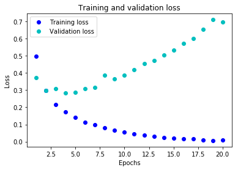

```python
history_dict = returned_dict['history'].history
loss_values = history_dict['loss']
val_loss_values = history_dict['val_loss']
acc_values = history_dict['acc']

epochs = range(1, len(acc_values) + 1)

plt.plot(epochs, loss_values, 'bo', label='Training loss')
plt.plot(epochs, val_loss_values, 'co', label='Validation loss')
plt.title('Training and validation loss')
plt.xlabel('Epochs')
plt.ylabel('Loss')
plt.legend()

plt.show()
```

The training loss dropped after each epoch, but the validation loss started to increase after the fourth epoch. This is a bit counter intuitive, as one might think that more training would yield better results. Let's check the accuracies to see if anything similar happened.

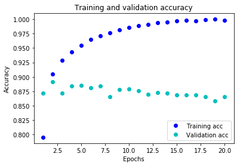

```python
plt.clf()

val_acc_values = history_dict['val_acc']

plt.plot(epochs, acc_values, 'bo', label='Training acc')
plt.plot(epochs, val_acc_values, 'co', label='Validation acc')
plt.title('Training and validation accuracy')
plt.xlabel('Epochs')
plt.ylabel('Accuracy')
plt.legend()

plt.show()
```

It appears that, like our loss, our validation accuracy gets worse after the first few tests while the training accuracy continues to improve.

This is because of a problem called overfitting. We trained our neural network based on the training data we gave it. Because we gave it the same data over and over again, it became very good at predicting the results from that data. However, it also specialized in that data. As specialization increased, the network's ability to generalize decreased. Decreased generalization meant that our network was more easily fooled by new data.

It looks like things started getting worse after the fourth epoch, so for the rest of our examples, we will only use four epochs.

To make things easier to see at once, for the rest of the examples, we will plot our losses and accuracies on the same plot. The following function does just that and gives our test accuracy, test loss, and training time.

```python
def graph_loss_and_accuracy(training_data):

    print('Loss: ' + str(round(training_data['loss'],4)) + '\nAccuracy: ' + str(round(training_data['accuracy'],4)) + '\nTraining time: '
          + str(round(training_data['time'],4)))

    history_dict = training_data['history'].history
    loss_values = history_dict['loss']
    val_loss_values = history_dict['val_loss']
    acc_values = history_dict['acc']
    val_acc_values = history_dict['val_acc']

    epochs = range(1, len(acc_values) + 1)

    plt.clf()

    plt.plot(epochs, loss_values, 'ro', label='Training loss')
    plt.plot(epochs, val_loss_values, 'ms', label='Validation loss')
    plt.plot(epochs, acc_values, 'bo', label='Training accuracy')
    plt.plot(epochs, val_acc_values, 'cs', label='Validation accuracy')
    plt.title('Training and validation loss')
    plt.xlabel('Epochs')
    plt.ylabel('Loss or Accuracy')
    plt.legend()

    plt.show()
```

```
Loss: 0.7706
Accuracy: 0.8508
Training time: 83.0271
```

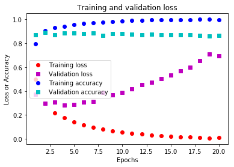

```python
test_accuracies[example_number, 0] = returned_dict['accuracy']
training_times[example_number, 0] = returned_dict['time']
example_number += 1
graph_loss_and_accuracy(returned_dict)
```

As the above information shows, our accuracy could be improved, and our loss leaves plenty of room to be desired. Let's see how things look after only four epochs. For later comparison, we will train each model five times to get more accurate numbers. Running these more times would be nice, but my laptop can only do so much before being overwhelmed.

Training and evaluating the following examples will be pretty cut and dry, so I advise skipping down to the analysis if you don't want to be bogged down in the details yet. I'll plot the results of the last training run for each example and give brief information if you do want to examine each example more closely. I've also emboldened what is different about each neural network compared to the basic neural network used in example 2.

### Example 2

- number of epochs = 4
- number of hidden layers = 2
- nodes per hidden layer = 16
- loss function = binary crossentropy
- activation function = rectified linear unit

```
Train on 15000 samples, validate on 10000 samples
Train on 15000 samples, validate on 10000 samples
Train on 15000 samples, validate on 10000 samples
Train on 15000 samples, validate on 10000 samples
Train on 15000 samples, validate on 10000 samples
Loss: 0.3074
Accuracy: 0.8746
Training time: 18.0867
```

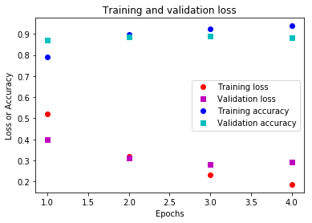

```python
for test_number in range(number_of_tests):
    returned_dict = create_train_and_evaluate_model()
    test_accuracies[example_number, test_number] = returned_dict['accuracy']
    training_times[example_number, test_number] = returned_dict['time']

example_number += 1
graph_loss_and_accuracy(returned_dict)
```

### Example 3

- number of epochs = 4
- **number of hidden layers = 1**
- nodes per hidden layer = 16
- loss function = binary crossentropy
- activation function = rectified linear unit

```
Train on 15000 samples, validate on 10000 samples
Train on 15000 samples, validate on 10000 samples
Train on 15000 samples, validate on 10000 samples
Train on 15000 samples, validate on 10000 samples
Train on 15000 samples, validate on 10000 samples
Loss: 0.3038
Accuracy: 0.8782
Training time: 18.1268
```

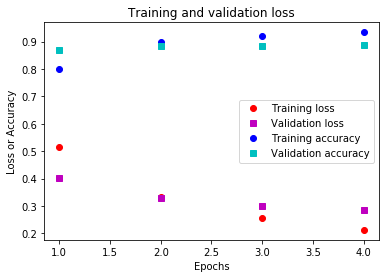

```python
for test_number in range(number_of_tests):
    returned_dict = create_train_and_evaluate_model(layer_quantity=1)
    test_accuracies[example_number, test_number] = returned_dict['accuracy']
    training_times[example_number, test_number] = returned_dict['time']

example_number += 1
graph_loss_and_accuracy(returned_dict)
```

### Example 4

- number of epochs = 4
- **number of hidden layers = 3**
- nodes per hidden layer = 16
- loss function = binary crossentropy
- activation function = rectified linear unit

```
Train on 15000 samples, validate on 10000 samples
Train on 15000 samples, validate on 10000 samples
Train on 15000 samples, validate on 10000 samples
Train on 15000 samples, validate on 10000 samples
Train on 15000 samples, validate on 10000 samples
Loss: 0.2985
Accuracy: 0.881
Training time: 21.8819
```

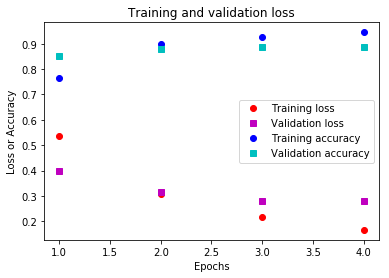

```python
for test_number in range(number_of_tests):
    returned_dict = create_train_and_evaluate_model(layer_quantity=3)
    test_accuracies[example_number, test_number] = returned_dict['accuracy']
    training_times[example_number, test_number] = returned_dict['time']

example_number += 1
graph_loss_and_accuracy(returned_dict)
```

### Example 5

```
Train on 15000 samples, validate on 10000 samples
Train on 15000 samples, validate on 10000 samples
Train on 15000 samples, validate on 10000 samples
Train on 15000 samples, validate on 10000 samples
Train on 15000 samples, validate on 10000 samples
Loss: 0.3151
Accuracy: 0.8738
Training time: 20.3562
```

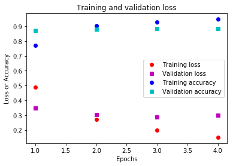

```python
for test_number in range(number_of_tests):
    returned_dict = create_train_and_evaluate_model(node_quantity=32)
    test_accuracies[example_number, test_number] = returned_dict['accuracy']
    training_times[example_number, test_number] = returned_dict['time']

example_number += 1
graph_loss_and_accuracy(returned_dict)
```

### Example 6

```
Train on 15000 samples, validate on 10000 samples
Train on 15000 samples, validate on 10000 samples
Train on 15000 samples, validate on 10000 samples
Train on 15000 samples, validate on 10000 samples
Train on 15000 samples, validate on 10000 samples
Loss: 0.3748
Accuracy: 0.8582
Training time: 22.1006
```

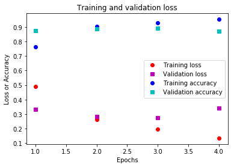

```python
for test_number in range(number_of_tests):
    returned_dict = create_train_and_evaluate_model(node_quantity=64)
    test_accuracies[example_number, test_number] = returned_dict['accuracy']
    training_times[example_number, test_number] = returned_dict['time']

example_number += 1
graph_loss_and_accuracy(returned_dict)
```

### Example 7

```
Train on 15000 samples, validate on 10000 samples
Train on 15000 samples, validate on 10000 samples
Train on 15000 samples, validate on 10000 samples
Train on 15000 samples, validate on 10000 samples
Train on 15000 samples, validate on 10000 samples
Loss: 0.3048
Accuracy: 0.8765
Training time: 21.5717
```

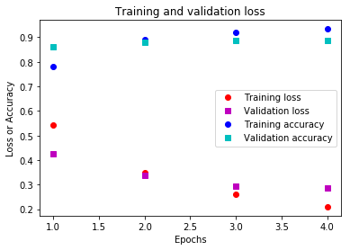

```python
for test_number in range(number_of_tests):
    returned_dict = create_train_and_evaluate_model(node_quantity=8)
    test_accuracies[example_number, test_number] = returned_dict['accuracy']
    training_times[example_number, test_number] = returned_dict['time']

example_number += 1
graph_loss_and_accuracy(returned_dict)
```

### Example 8

```
Train on 15000 samples, validate on 10000 samples
Train on 15000 samples, validate on 10000 samples
Train on 15000 samples, validate on 10000 samples
Train on 15000 samples, validate on 10000 samples
Train on 15000 samples, validate on 10000 samples
Loss: 0.0883
Accuracy: 0.8824
Training time: 19.2559
```

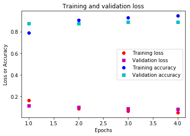

```python
for test_number in range(number_of_tests):
    returned_dict = create_train_and_evaluate_model(loss_function='mse')
    test_accuracies[example_number, test_number] = returned_dict['accuracy']
    training_times[example_number, test_number] = returned_dict['time']
example_number += 1
graph_loss_and_accuracy(returned_dict)
```

### Example 9

```
Train on 15000 samples, validate on 10000 samples
Train on 15000 samples, validate on 10000 samples
Train on 15000 samples, validate on 10000 samples
Train on 15000 samples, validate on 10000 samples
Train on 15000 samples, validate on 10000 samples
Loss: 0.3038
Accuracy: 0.877
Training time: 21.6955
```

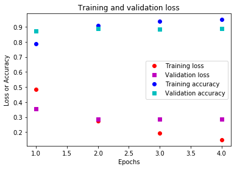

```python
for test_number in range(number_of_tests):
    returned_dict = create_train_and_evaluate_model(activation_function='tanh')
    test_accuracies[example_number, test_number] = returned_dict['accuracy']
    training_times[example_number, test_number] = returned_dict['time']

example_number += 1
graph_loss_and_accuracy(returned_dict)
```

```python
avg_training_times = np.mean(training_times[1:], axis=1)
avg_test_accuracies = np.mean(test_accuracies[1:], axis=1)

print(avg_training_times)
print(avg_test_accuracies)
```

```
[18.76719411 18.04768998 20.09093555 20.69133952 23.01454626 19.48761259
 19.80318583 19.96571349]
[0.878472 0.882416 0.87576  0.867336 0.850504 0.878184 0.870592 0.878056]
```

## Analysis

Below, I've plotted the average accuracies and training times from each of the previous examples. I've included our original 20 epoch example to compare our averages to. It is the point in the bottom right corner. It took approximately four times as long to train and still has one of the worst accuracies. Let's get rid of the point so we can look closer at our other averages.

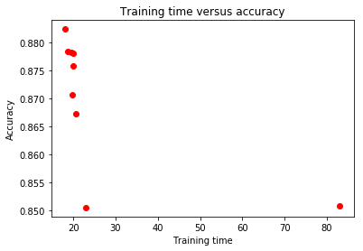

```python
plt.clf()

plt.plot(training_times[0,0], test_accuracies[0,0], 'ro')
plt.plot(avg_training_times, avg_test_accuracies, 'ro')
plt.title('Training time versus accuracy')
plt.xlabel('Training time')
plt.ylabel('Accuracy')

plt.show()
```

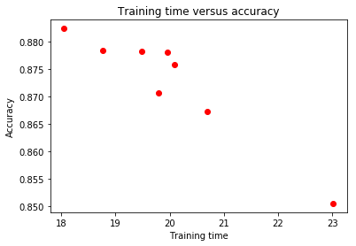

```python
plt.clf()

plt.plot(avg_training_times, avg_test_accuracies, 'ro')
plt.title('Training time versus accuracy')
plt.xlabel('Training time')
plt.ylabel('Accuracy')

plt.show()
```

Our results show us that there is a negative correlation between training time and accuracy for our models. Our problem is similar to the problem we had in our first example. The two data points with the worst accuracy and most time taken are the examples that used 64 nodes per hidden layer and 32 nodes per hidden layer. The 64 nodes per hidden layer was the worst of the two. These examples were over fit, because the more nodes used in hidden layers, the more detailed the boundary that the model describes between categories. These detailed models are bad at generalizing, and as such were thrown off by new inputs. To rub salt in the wound, these over fit models took longer to train because they have many times more computations to run. Our model with the shortest training time and best accuracy was actually the most generalized model we made. Our most efficient model only had one hidden layer of 16 nodes.

The rest are easily clumped into a group, but let's see how different these models really are by using relative difference.

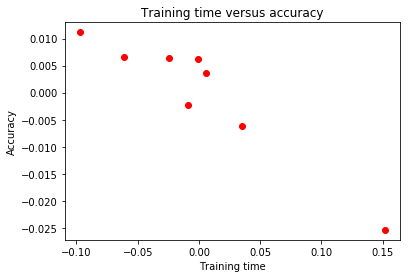

```python
plt.clf()

#std deviation maybe?
avg_training_time = np.mean(avg_training_times)
avg_test_accuracy = np.mean(avg_test_accuracies)

relative_time_deviations = (avg_training_times - avg_training_time) / avg_training_time
relative_accuracy_deviations = (avg_test_accuracies - avg_test_accuracy) / avg_test_accuracy

plt.plot(relative_time_deviations, relative_accuracy_deviations, 'ro')
plt.title('Training time versus accuracy')
plt.xlabel('Training time')
plt.ylabel('Accuracy')

plt.show()
```

As we can see, our neural networks had very different training times, which range from 10 percent faster than average to 15 percent slower than average. However, our accuracies did not range nearly as much. Our best accuracy was one percent above average while our worst accuracy was 2.5 percent below average. While one percent may seem small, especially for something as inconsequential as our examples, one percent can have disastrous or tremendous results in other contexts.

Finally, it is important to remember that the general lesson of these experiments, that overfitting can be time consuming and decrease accuracy, but it is also important not to believe that every model will behave the same way when modified as they are in the previous examples. The same architecture could even yield different results using the same architecture with different training data, and more complex problems will likely require more complex solutions.